# Illusion Sensitivity and Phenomenological Control

Cleaning

Published

October 30, 2026

# Data Preparation

```r
library(tidyverse)
library(ggdist)
library(ggside)
library(easystats)
library(patchwork)

data_ppt <- read.csv("https://raw.githubusercontent.com/RealityBending/IllusionGamePhenomenologicalControl/refs/heads/main/data/rawdata_participants.csv")
data_ig <- read.csv("https://raw.githubusercontent.com/RealityBending/IllusionGamePhenomenologicalControl/refs/heads/main/data/rawdata_illusion.csv") |>
    mutate(
        Illusion_Effect = ifelse(sign(Illusion_Strength) > 0, "Incongruent", "Congruent"),
        Task_Difficulty = abs(Illusion_Difference),
        Condition_Illusion = case_when(
            Illusion_Effect == "Congruent" ~ "Congruent",
            Illusion_Effect == "Incongruent" & Illusion_Strength <= median(Illusion_Strength[Illusion_Effect == "Incongruent"], na.rm = TRUE) ~ "Mild",
            Illusion_Effect == "Incongruent" & Illusion_Strength > median(Illusion_Strength[Illusion_Effect == "Incongruent"], na.rm = TRUE) ~ "Strong"
        ),
        Condition_Difficulty = datawizard::categorize(
            Task_Difficulty,
            split = "quantile",
            n_groups = 2,
            labels = c("Hard", "Easy")
        ),
        .by = "Illusion_Type"
    )

n_trials_raw <- nrow(data_ig)
```

The initial sample consisted of 500 participants (Mean age = 38.6, SD = 13.1, range: [18, 75]; Gender: 49.4% women, 49.8% men, 0.80% non-binary; Education: Bachelor, 49.60%; Doctorate, 2.80%; Elementary school, 0.20%; High school, 27.40%; Master, 18.20%; Other, 1.80%), for a total trial number of 240000.

## Experiment Duration

The experiment’s median duration is 47.96 min (50% HDI [40.85, 48.98]).

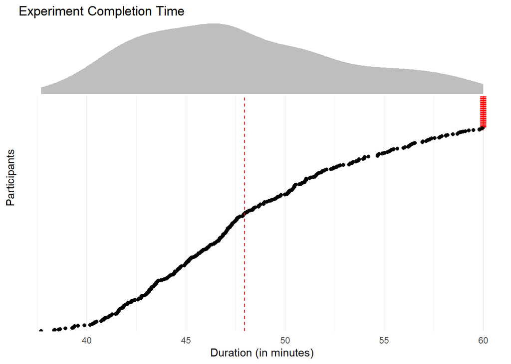

```r
data_ppt |>
    mutate(
        Participant = fct_reorder(Participant, Experiment_Duration),
        Category = ifelse(Experiment_Duration > 60, "extra", "ok"),
        Duration = ifelse(Experiment_Duration > 60, 60, Experiment_Duration)
    ) |>
    ggplot(aes(y = Participant, x = Duration)) +
    geom_point(aes(color = Category, shape = Category)) +
    geom_vline(xintercept = median(data_ppt$Experiment_Duration), color = "red", linetype = "dashed") +
    scale_shape_manual(values = c("extra" = 3, ok = 19)) +
    scale_color_manual(values = c("extra" = "red", ok = "black")) +
    guides(color = "none", shape = "none") +
    ggside::geom_xsidedensity(data = filter(data_ppt, Experiment_Duration < 60), aes(x=Experiment_Duration), fill = "grey", color = NA) +
    ggside::scale_xsidey_continuous(expand = c(0, 0)) +
    labs(
        title = "Experiment Completion Time",
        x = "Duration (in minutes)",
        y = "Participants"
    ) +
    theme_minimal() +
    ggside::theme_ggside_void() +
    theme(
        ggside.panel.scale = .3,
        axis.text.y = element_blank(),
        panel.grid.major.y = element_blank()
    )
```

## Personality Questionnaires

### IPIP6

```r
ipip6 <- select(data_ppt, starts_with("ipip_"))
ipip6[grepl("_R", names(ipip6))] <- 8 - ipip6[grepl("_R", names(ipip6))]

data_ppt$IPIP6_Extraversion <- rowMeans(ipip6[grepl("Ext", names(ipip6))])
data_ppt$IPIP6_Conscientiousness <- rowMeans(ipip6[grepl("Cons", names(ipip6))])
data_ppt$IPIP6_Neuroticism <- rowMeans(ipip6[grepl("Neuro", names(ipip6))])
data_ppt$IPIP6_Openness <- rowMeans(ipip6[grepl("Open", names(ipip6))])
data_ppt$IPIP6_HonestyHumility <- rowMeans(ipip6[grepl("HonHum", names(ipip6))])
data_ppt$IPIP6_Agreeableness <- rowMeans(ipip6[grepl("Agr", names(ipip6))])
```

### PID-5

```r
pid5 <- select(data_ppt, starts_with("pid_"))

data_ppt$PID5_Disinhibition <- rowMeans(pid5[grepl("Dis", names(pid5))])
data_ppt$PID5_Detachment <- rowMeans(pid5[grepl("Det", names(pid5))])
data_ppt$PID5_NegativeAffect <- rowMeans(pid5[grepl("NegAff", names(pid5))])
data_ppt$PID5_Antagonism <- rowMeans(pid5[grepl("Ant", names(pid5))])
data_ppt$PID5_Psychoticism <- rowMeans(pid5[grepl("Psy", names(pid5))])
```

## Exclusions

### PCS

#### PCS (registered)

The registered protocol specified that participants failing any of the three PCS attention checks would be excluded: not reporting hearing “Hello” at the beginning of the experiment, reporting that no balls were presented on the screen, and pressing the space bar fewer than 5 times upon seeing the words “PLEASE WAIT” on the screen.

```r
outliers_pcs1 <- data_ppt[data_ppt$pcs_hello != "Hello", "Participant"]
outliers_pcs2 <- data_ppt[data_ppt$pcs_noballs == TRUE, "Participant"]
outliers_pcs3 <- data_ppt[data_ppt$pcs_press < 5, "Participant"] # get PP count
outliers_pcs <- unique(c(outliers_pcs1, outliers_pcs2))
```

10 participants failed the “Hello” check, 9 reported that no balls were presented, and 189 (37.80%) failed the space bar check (177 of whom did not press at all; 181 of whom had passed the first two checks). In total, 200 participants failed at least one of the three checks.

#### PCS (unregistered)

Departing from the registered protocol, the space bar check is not applied in the unregistered analysis, as it was failed by a disproportionate number of participants compared with the other two checks. The fully registered sample, in which all three checks are applied, is built under *Final Sample → Registered*, and both samples are analysed (see the analysis report for the response patterns of participants who failed this check).

#### Apply

Participants failing the first two checks (19, 3.80%) are removed from both samples. Participants failing the space bar check are flagged (`PCS_Outlier_Press`) and removed in the fully registered sample only.

```r
data_ppt$PCS_Outlier_Press <- ifelse(data_ppt$Participant %in% outliers_pcs3, TRUE, FALSE)
data_ppt <- filter(data_ppt, !Participant %in% outliers_pcs)
data_ig <- filter(data_ig, !Participant %in% outliers_pcs)

# Kept for the fully registered sample (see Final Sample → Registered)
data_ppt_pcs <- data_ppt
data_ig_pcs <- data_ig
```

**PCS Exclusions Table**

```r
pcs_ex_tib <- bind_rows(
  tibble(Participant = outliers_pcs1, Reason = "Failed 'Hello' check"),
  tibble(Participant = outliers_pcs2, Reason = "Reported no balls"),
)

pcs_ex_tib |>
  knitr::kable(caption = "Exclusions From Phenomenological Control Scale") |>
  kableExtra::scroll_box(height = "300px") |>
  kableExtra::kable_styling()
```

Exclusions From Phenomenological Control Scale

| Participant | Reason |
| --- | --- |
| S084 | Failed 'Hello' check |
| S151 | Failed 'Hello' check |
| S165 | Failed 'Hello' check |
| S206 | Failed 'Hello' check |
| S232 | Failed 'Hello' check |
| S293 | Failed 'Hello' check |
| S310 | Failed 'Hello' check |
| S323 | Failed 'Hello' check |
| S389 | Failed 'Hello' check |
| S412 | Failed 'Hello' check |
| S022 | Reported no balls |
| S054 | Reported no balls |
| S063 | Reported no balls |
| S226 | Reported no balls |
| S240 | Reported no balls |
| S291 | Reported no balls |
| S390 | Reported no balls |
| S430 | Reported no balls |
| S439 | Reported no balls |

**PCS Exclusions Graph**

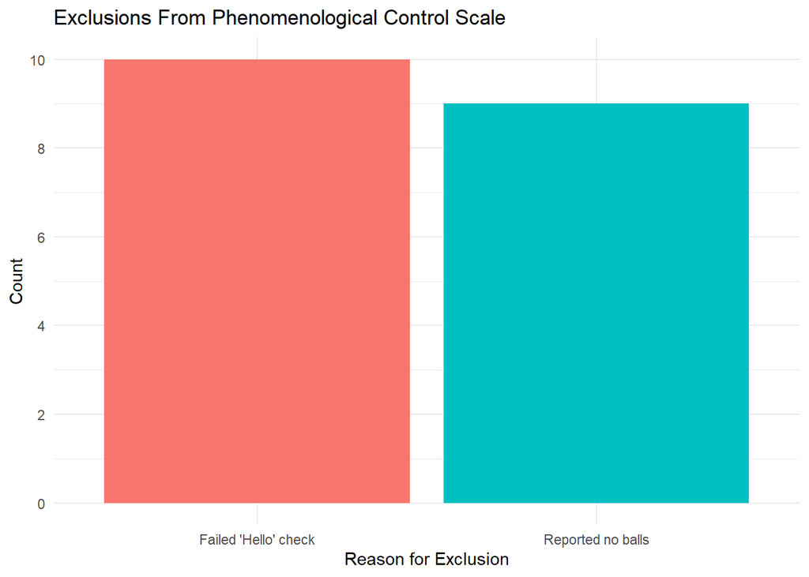

```r
pcs_ex_bar <- pcs_ex_tib |>
  ggplot(aes(x = Reason, fill = Reason)) +
  geom_bar() +
  scale_y_continuous(breaks = scales::pretty_breaks()) +
    labs(
    title = "Exclusions From Phenomenological Control Scale",
    x = "Reason for Exclusion",
    y = "Count",
  ) +
  theme_minimal() +
  guides(fill = "none")

pcs_ex_bar
```

### Illusion Game Participants

#### Error Rate (registered)

We removed participants with an error rate > 45% (suggesting chance-level, i.e., random, responding) for any of the illusion types. Outliers detected in the first block were discarded entirely (suggesting that they did not properly do the task), but if only the second set was bad, then only the second set was discarded (suggesting that they got “bored” when having to re-do the task), as the illusion sensitivity can still be estimated, albeit with less precision.

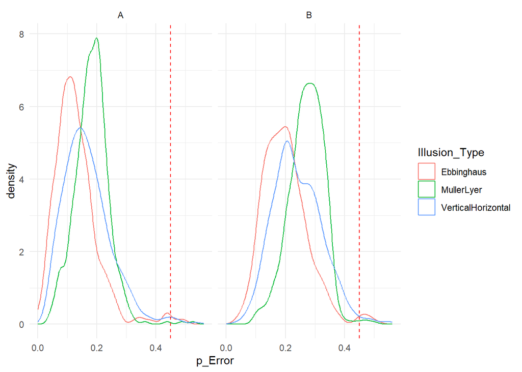

```r
data_error <- data_ig |>
    summarize(
        p_Error = sum(Error) / n(),
        .by = c("Participant", "Illusion_Type", "Block")
    ) |>
    arrange(desc(p_Error))

outliers_error <- filter(data_error, p_Error > 0.45)
outliers_error_full <- unique(filter(outliers_error, Block == "A")$Participant)
outliers_error_half <- unique(filter(outliers_error, Block == "B")$Participant)
outliers_error_half <- outliers_error_half[!(outliers_error_half %in% outliers_error_full)]

data_error |>
    ggplot(aes(x = p_Error)) +
    geom_density(aes(color = Illusion_Type)) +
    geom_vline(xintercept = 0.45, linetype = "dashed", color = "red") +
    facet_wrap(~Block) +
    theme_minimal()
```

Based on error rate, 8 participants were excluded entirely and 7 participants had their second block removed.

#### Response Time (registered)

Participants whose mean RT was slower than the group average (possibly indicative of a different strategy) were also excluded from the analysis (RT > 4 SD above the mean).

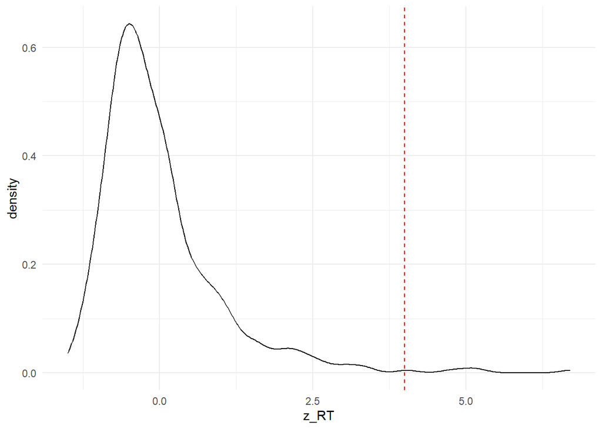

```r
data_rt <- data_ig |>
    summarize(Mean_RT = mean(RT), .by = "Participant") |>
    mutate(z_RT = as.numeric(standardize(Mean_RT)))

outliers_rt <- filter(data_rt, z_RT > 4)$Participant

data_rt |>
    ggplot(aes(x = z_RT)) +
    geom_density() +
    geom_vline(xintercept = 4, linetype = "dashed", color = "red") +
    theme_minimal()
```

Based on RT, 5 participants were excluded entirely (0 of whom were also flagged by the error-rate criterion).

#### Sensitivity: Block-Wise RT Rule (unregistered)

The block-specific rule (registered for error rates only) applied to the RT criterion, as in the initial submission. Participants are flagged only; the flags are used in the corresponding sensitivity analysis.

```r
data_rt_block <- data_ig |>
    summarize(Mean_RT = mean(RT), .by = c("Participant", "Illusion_Type", "Block")) |>
    mutate(z_RT = as.numeric(standardize(Mean_RT)), .by = c("Illusion_Type", "Block"))

outliers_rtblock_full <- unique(filter(data_rt_block, z_RT > 4, Block == "A")$Participant)
outliers_rtblock_half <- unique(filter(data_rt_block, z_RT > 4, Block == "B")$Participant)
outliers_rtblock_half <- outliers_rtblock_half[!(outliers_rtblock_half %in% outliers_rtblock_full)]

data_ppt$IG_Outlier_RTBlock_Full <- data_ppt$Participant %in% outliers_rtblock_full
data_ppt$IG_Outlier_RTBlock_Half <- data_ppt$Participant %in% outliers_rtblock_half
```

#### Apply

```r
outliers_full <- unique(c(outliers_error_full, outliers_rt))
outliers_half <- outliers_error_half[!(outliers_error_half %in% outliers_full)]

data_ig <- data_ig |>
    filter(!Participant %in% outliers_full) |>
    filter(!((Block == "B") & (Participant %in% outliers_half)))

data_ppt <- filter(data_ppt, !Participant %in% outliers_full)
data_ig <- filter(data_ig, Participant %in% data_ppt$Participant)
```

**IG Exclusions Table**

```r
ig_ex_tib <- bind_rows(
  tibble(Participant = outliers_error_full, Reason = "Error rate > 45% (block A)", "Extent of Exclusion" = "Participant-level"),
  tibble(Participant = outliers_error_half, Reason = "Error rate > 45% (block B only)", "Extent of Exclusion" = "Block-level"),
  tibble(Participant = outliers_rt, Reason = "Mean RT > 4 SD", "Extent of Exclusion" = "Participant-level")
)

ig_ex_tib |>
  knitr::kable(caption = "Exclusions From Illusion Game") |>
  kableExtra::scroll_box(height = "300px") |>
  kableExtra::kable_styling()
```

Exclusions From Illusion Game

| Participant | Reason | Extent of Exclusion |
| --- | --- | --- |
| S415 | Error rate > 45% (block A) | Participant-level |
| S465 | Error rate > 45% (block A) | Participant-level |
| S266 | Error rate > 45% (block A) | Participant-level |
| S136 | Error rate > 45% (block A) | Participant-level |
| S354 | Error rate > 45% (block A) | Participant-level |
| S353 | Error rate > 45% (block A) | Participant-level |
| S365 | Error rate > 45% (block A) | Participant-level |
| S195 | Error rate > 45% (block A) | Participant-level |
| S102 | Error rate > 45% (block B only) | Block-level |
| S115 | Error rate > 45% (block B only) | Block-level |
| S364 | Error rate > 45% (block B only) | Block-level |
| S366 | Error rate > 45% (block B only) | Block-level |
| S174 | Error rate > 45% (block B only) | Block-level |
| S334 | Error rate > 45% (block B only) | Block-level |
| S349 | Error rate > 45% (block B only) | Block-level |
| S355 | Mean RT > 4 SD | Participant-level |
| S184 | Mean RT > 4 SD | Participant-level |
| S024 | Mean RT > 4 SD | Participant-level |
| S347 | Mean RT > 4 SD | Participant-level |
| S268 | Mean RT > 4 SD | Participant-level |

**IG Exclusions Graph**

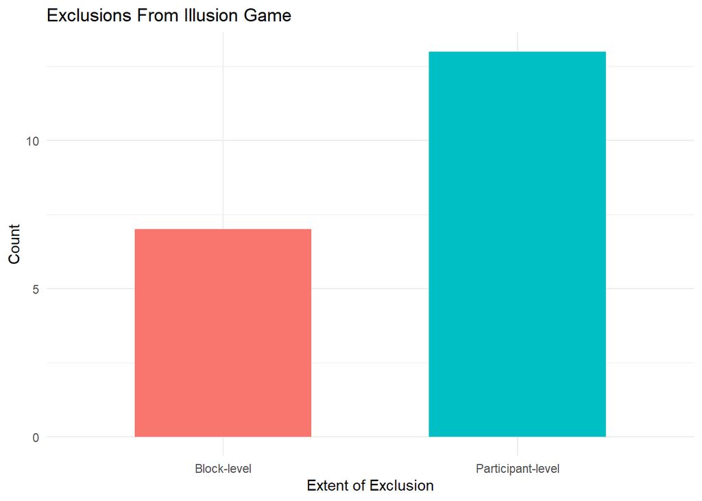

```r
ig_ex_bar <- ig_ex_tib |>
  ggplot(aes(x = `Extent of Exclusion`, fill = `Extent of Exclusion`)) +
  geom_bar(width = 0.6) +
  scale_x_discrete(labels = scales::label_wrap(15)) +
  scale_y_continuous(breaks = scales::pretty_breaks()) +
  labs(
    title = "Exclusions From Illusion Game",
    x = "Extent of Exclusion",
    y = "Count",
  ) +
  theme_minimal() +
  guides(fill = "none")

ig_ex_bar
```

### Illusion Game Trials

#### Registered

The Stage 1 protocol referred to the removal of “problematic participants and trials” but did not specify a trial-level criterion, so no trial-level exclusion was registered.

#### Unregistered

Departing from the registered protocol, individual extreme trials (RT < 0.2 s or > 5 s; Thériault et al., 2024) were flagged to mitigate the risk of confounding effects driven by extreme speed or accuracy strategies.

```r
data_ig$RT_Outlier <- data_ig$RT <= 0.2 | data_ig$RT >= 5
n_before <- nrow(data_ig)
n_removed <- sum(data_ig$RT_Outlier)
```

This flagged 864 trials (0.39% of total; 298 faster than 0.2 s and 566 slower than 5 s).

#### Apply

The flagged trials are kept in the saved data (column `RT_Outlier`) and are only removed in the corresponding sensitivity analysis (see the analysis report). They are not flagged in the fully registered sample.

### Final Sample

```r
plot_age <- function(data) {
  data |> # To match the binwidth
    ggplot(aes(x = data)) +
    geom_histogram(aes(x = Age, fill = Gender), bins = 28) +
    geom_vline(xintercept = mean(data$Age), color = "red", linewidth = 1.5) +
    scale_fill_manual(values = c("Male" = "#64B5F6", "Female" = "#F06292", "Other" = "orange")) +
    scale_x_continuous(expand = c(0, 0)) +
    scale_y_continuous(expand = c(0, 0)) +
    labs(title = "Age", y = "Number of Participants", color = NULL, subtitle = "Distribution of participants' age") +
    theme_modern(axis.title.space = 10) +
    theme(
        plot.title = element_text(size = rel(1.2), face = "bold", hjust = 0),
        plot.subtitle = element_text(size = rel(1.2), vjust = 7),
        axis.text.y = element_text(size = rel(1.1)),
        axis.text.x = element_text(size = rel(1.1)),
        axis.title.x = element_blank()
    )
}

plot_education <- function(data) {
  data |>
    mutate(Education = fct_relevel(Education, "Other", "Elementary school", "High school", "Bachelor", "Master", "Doctorate")) |>
    ggplot(aes(x = Education)) +
    geom_bar(aes(fill = Education)) +
    scale_x_discrete(labels = scales::label_wrap(10)) +
    scale_y_continuous(expand = c(0, 0), breaks = scales::pretty_breaks()) +
    scale_fill_viridis_d(guide = "none") +
    labs(title = "Education", y = "Number of Participants", subtitle = "Participants per achieved education level") +
    theme_modern(axis.title.space = 15) +
    theme(
        plot.title = element_text(size = rel(1.2), face = "bold", hjust = 0),
        plot.subtitle = element_text(size = rel(1.2), vjust = 7),
        axis.text.y = element_text(size = rel(1.1)),
        axis.text.x = element_text(size = rel(1.1)),
        axis.title.x = element_blank()
    )
}

plot_ethnicity <- function(data) {
  data |>
    mutate(Ethnicity = ifelse(is.na(Ethnicity), "Prefer not to answer", Ethnicity)) |>
    mutate(Freq = format_percent(n() / nrow(data), digits=1), .by=Ethnicity) |>
    mutate(Ethnicity = fct_infreq(paste0(Ethnicity, " (", Freq, ")"))) |>
    ggplot(aes(x = "", fill = Ethnicity)) +
    geom_bar() +
    coord_polar("y") +
    see::scale_fill_social_d() +
    labs(title = "Ethnicity", subtitle = "Self-declared ethnicity") +
    theme_minimal() +
    theme(
      axis.text.x = element_blank(),
      axis.title.x = element_blank(),
      axis.text.y = element_blank(),
      axis.title.y = element_blank(),
      plot.title = element_text(size = rel(1.2), face = "bold", hjust = 0),
      plot.subtitle = element_text(size = rel(1.2))
    )
}
```

#### Registered

This sample applies all registered exclusion criteria, including the space bar check, and no unregistered step. The Illusion Game criteria are recomputed on the participants who passed all three PCS checks.

```r
ig_reg <- filter(data_ig_pcs, !Participant %in% outliers_pcs3)

err_reg <- ig_reg |>
    summarize(p_Error = sum(Error) / n(), .by = c("Participant", "Illusion_Type", "Block")) |>
    filter(p_Error > 0.45)
reg_full <- unique(filter(err_reg, Block == "A")$Participant)
reg_half <- unique(filter(err_reg, Block == "B")$Participant)

rt_reg <- ig_reg |>
    summarize(Mean_RT = mean(RT), .by = "Participant") |>
    mutate(z_RT = as.numeric(standardize(Mean_RT)))
reg_full <- unique(c(reg_full, filter(rt_reg, z_RT > 4)$Participant))
reg_half <- reg_half[!(reg_half %in% reg_full)]

data_ig_registered <- ig_reg |>
    filter(!Participant %in% reg_full) |>
    filter(!((Block == "B") & (Participant %in% reg_half)))
data_ppt_registered <- filter(data_ppt_pcs, Participant %in% data_ig_registered$Participant)
```

Of the 300 participants who passed all three PCS checks, 5 were fully excluded and 3 had their second block removed.

**Summary**

The fully registered sample includes 295 participants (Mean age = 38.1, SD = 12.9, range: [18, 73]; Gender: 48.8% women, 49.8% men, 1.36% non-binary; Education: Bachelor, 49.49%; Doctorate, 1.36%; Elementary school, 0.34%; High school, 28.47%; Master, 18.98%; Other, 1.36%), for a total trial number of 140880.

**Age and Gender**

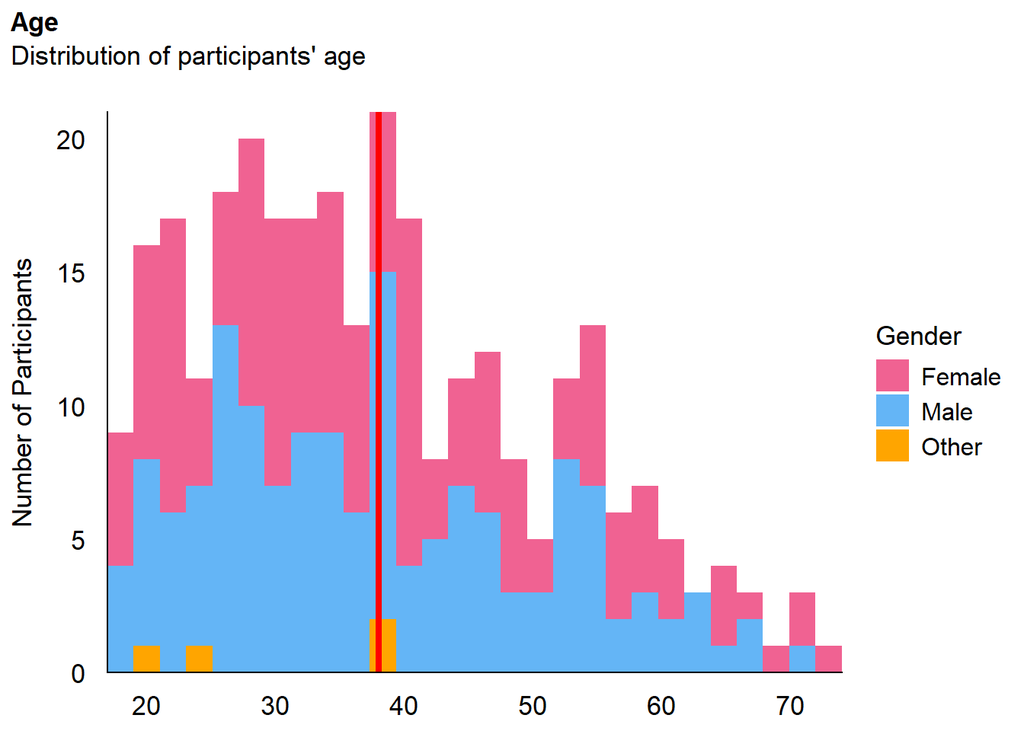

```r
plot_age(data_ppt_registered)
```

**Education**

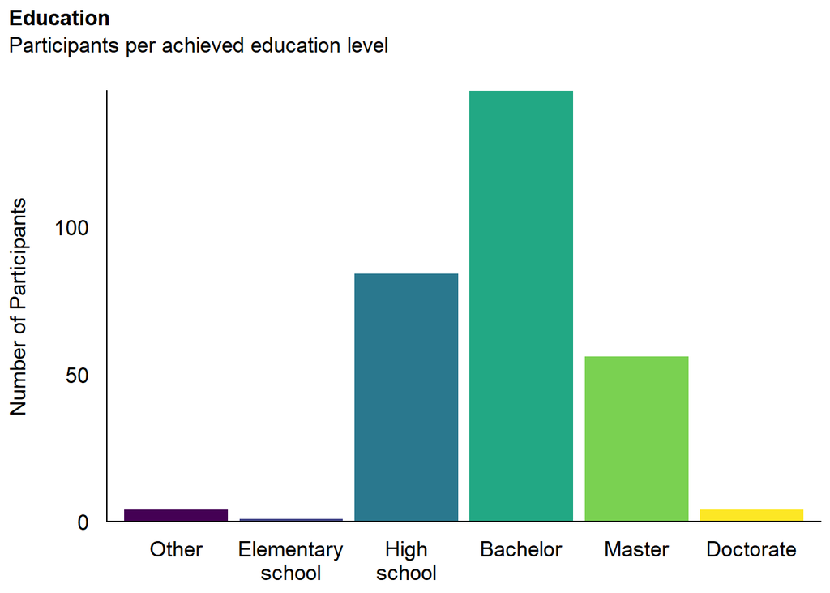

```r
plot_education(data_ppt_registered)
```

**Ethnicity**

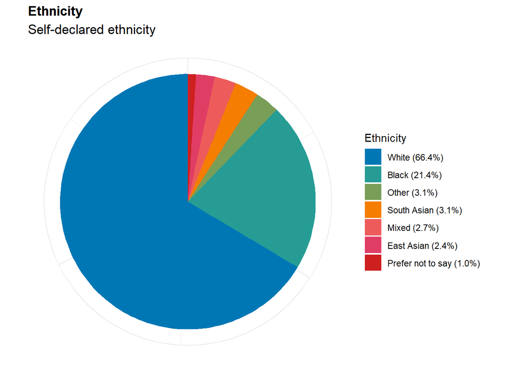

```r
plot_ethnicity(data_ppt_registered)
```

#### Without the Space Bar Check (unregistered)

**Summary**

The final sample includes 468 participants (Mean age = 38.7, SD = 13.2, range: [18, 75]; Gender: 48.7% women, 50.4% men, 0.85% non-binary; Education: Bachelor, 48.50%; Doctorate, 2.78%; Elementary school, 0.21%; High school, 28.42%; Master, 18.16%; Other, 1.92%), for a total trial number of 222960.

**Age and Gender**

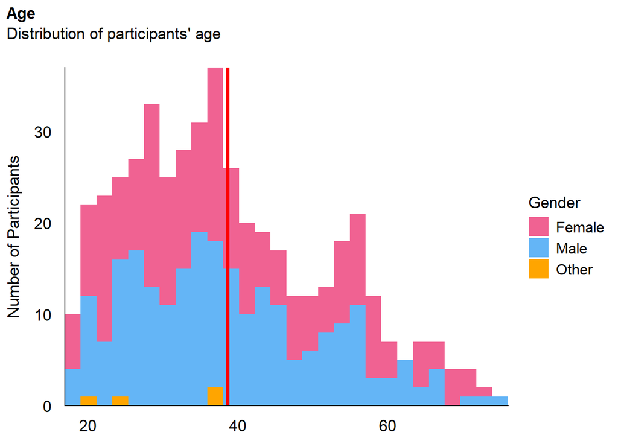

```r
plot_age(data_ppt)
```

**Education**

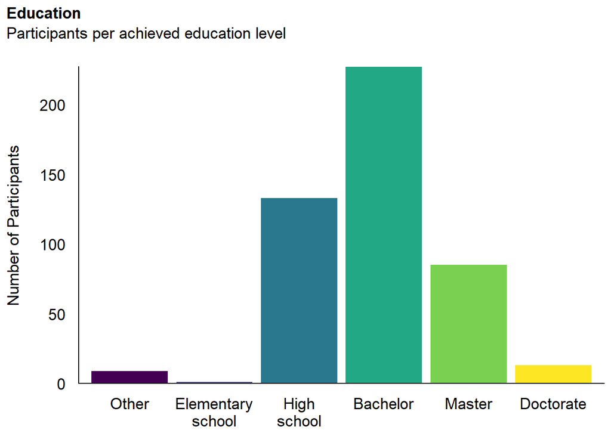

```r
plot_education(data_ppt)
```

**Ethnicity**

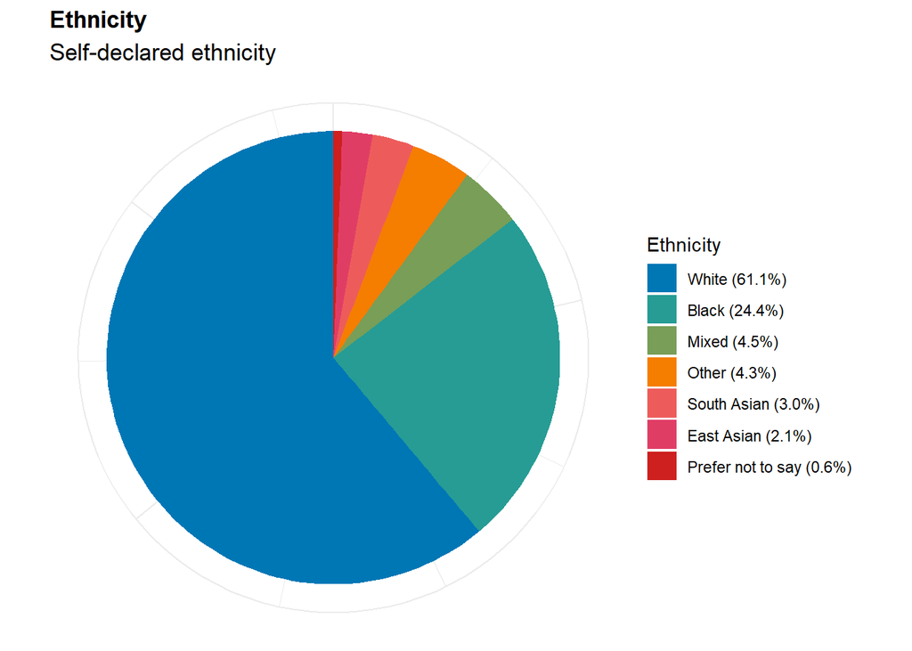

```r
plot_ethnicity(data_ppt)
```

# Exclusion Counts

Saved for the flow diagram (built in the analysis report, which adds the sensitivity-only exclusions).

```r
exclusion_counts <- list(
  n_raw = nrow(data_ppt) + length(outliers_pcs) + length(outliers_full),
  # n_raw: final sample + participants excluded by the PCS and Illusion Game criteria
  n_trials_raw = n_trials_raw,
  pcs_hello = length(outliers_pcs1),
  pcs_balls = length(outliers_pcs2),
  n_after_pcs = nrow(data_ppt_pcs),
  pcs_press = sum(data_ppt_pcs$PCS_Outlier_Press),
  # Fully registered sample
  reg_n_pass = length(unique(ig_reg$Participant)),
  reg_error_full = length(unique(filter(err_reg, Block == "A")$Participant)),
  reg_rt_full = length(setdiff(filter(rt_reg, z_RT > 4)$Participant, unique(filter(err_reg, Block == "A")$Participant))),
  reg_half = length(reg_half),
  reg_n = nrow(data_ppt_registered),
  reg_trials = nrow(data_ig_registered),
  # Space bar check not applied
  error_full = length(outliers_error_full),
  rt_full = length(setdiff(outliers_rt, outliers_error_full)),
  half = length(outliers_half),
  n = nrow(data_ppt),
  trials = nrow(data_ig),
  trials_rt_outlier = n_removed
)
saveRDS(exclusion_counts, "figures/exclusion_counts.rds")
```

# Save

```r
write.csv(data_ppt, "../data/data_participants.csv", row.names = FALSE)
write.csv(data_ig, "../data/data_illusion.csv", row.names = FALSE)
write.csv(data_ppt_registered, "../data/data_participants_registered.csv", row.names = FALSE)
write.csv(data_ig_registered, "../data/data_illusion_registered.csv", row.names = FALSE)
```